# Intoxication Detection Project

Norman, Elsa; McCartney, Connor; Dertke, Mike

Last Updated: Fri Dec 12, 2025

**Using smartphone accelerometer data to detect user intoxication**

*This project uses a dataset from the UC Irvine Machine Learning Repository at https://archive.ics.uci.edu/dataset/515/bar+crawl+detecting+heavy+drinking. The dataset contains smartphone accelerometer data and TAC measurements for 13 subjects while participating in the Ohio State University Annual Senior Bar Crawl. This project investigates whether smartphone accelerometer data can be used to detect intoxication for the 13 subjects in this study.*

## Models

We need to first load the necessary libraries.

```r
library(randomForest)
library(gbm)
library(tree)
library(e1071)
library(class)
library(ggplot2)
```

Load in dataset and split into testing and training values

```r
set.seed(52)
data = read.csv("bar+crawl+detecting+heavy+drinking\\data\\average_accel.csv")

data$label = as.factor(data$label)

# rerrange rows to ensure representative sampling
data = data[sample(nrow(data)), ]

data_rows = floor(0.80 * nrow(data))
train_indices = sample(c(1:nrow(data)), data_rows)
train_data = data[train_indices,]
test_data = data[-train_indices,]
```

```r
accuracies = rep(NA, 8)
precisions = rep(NA, 8)
recalls = rep(NA, 8)
f1s = rep(NA, 8)
```

### 1. Logistic Regression Model

Run the logistic regression model and obtain accuracy, precision, recall, and F1-score.

```r
model = glm(label ~ ., data = train_data, family = binomial)

test_labels = factor(test_data$label, labels = c("sober", "intoxicated"))

pred_probs = predict(model, test_data, type = "response")
pred = factor(ifelse(pred_probs < 0.5, "sober", "intoxicated"))


tp = sum(test_labels == pred & pred == "intoxicated")
fp = sum(test_labels != pred & pred == "intoxicated")
tn = sum(test_labels == pred & pred == "sober")
fn = sum(test_labels != pred & pred == "sober")

accuracy = mean(test_labels == pred); accuracies[1] = accuracy
precision = tp / (tp + fp); precisions[1] = precision
recall = tp / (tp + fn); recalls[1] = recall
f1 = 2 * (precision * recall) / (precision + recall); f1s[1] = f1

cat(noquote(paste0("Logistic Regression\n\nAccuracy: ", round(accuracy,4),
                   "\nPrecision: ", round(precision,4),
                   "\nRecall: ", round(recall,4),
                   "\nF1: ", round(f1,4), "\n\n")))
```

```
## Logistic Regression
##
## Accuracy: 0.6954
## Precision: 0.5472
## Recall: 0.1629
## F1: 0.2511
```

```r
conf_matrix = table(Predicted = pred, True = test_labels)
cm_swapped = conf_matrix[c(2, 1), ] # swap rows
cm_swapped
```

```
##              True
## Predicted     sober intoxicated
##   sober         366         149
##   intoxicated    24          29
```

### 2. Bagging Model

First conduct parameter tuning on mtry, then run the bagging model and obtain accuracy, precision, recall, and F1-score.

```r
bag.acc.values = rep(NA, 4)

for (i in 1:4) {
  set.seed(12)
  bag = randomForest(label ~ ., data = train_data, mtry = i, importance = TRUE)
  pred = predict(bag, test_data, type="response")
  test_labels = test_data$label
  bag.acc.values[i] = mean(test_labels == pred)
}

mtry = which.max(bag.acc.values)

names(bag.acc.values) = c(1,2,3,4)
bag.acc.values
```

```
##         1         2         3         4
## 0.7517606 0.7676056 0.7693662 0.7517606
```

```r
set.seed(12)
bag = randomForest(label ~ ., data = train_data, mtry = mtry, importance = TRUE)
bag
```

```
##
## Call:
##  randomForest(formula = label ~ ., data = train_data, mtry = mtry,      importance = TRUE)
##                Type of random forest: classification
##                      Number of trees: 500
## No. of variables tried at each split: 3
##
##         OOB estimate of  error rate: 24.43%
## Confusion matrix:
##      0   1 class.error
## 0 1153 284   0.1976340
## 1  271 564   0.3245509
```

```r
importance(bag)
```

```
##          0        1 MeanDecreaseAccuracy MeanDecreaseGini
## m 66.74310 23.91589             97.94100         343.8193
## x 38.19632 24.10835             50.72537         241.1403
## y 29.26552 12.84234             35.10800         198.0462
## z 70.25633 27.44973             83.88149         271.6590
```

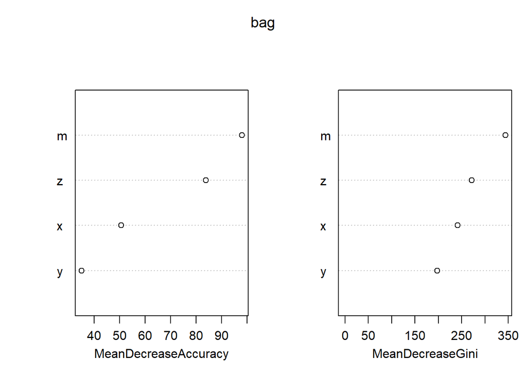

```r
varImpPlot(bag)
```

```r
# test accuracy
pred = predict(bag, test_data, type="response")


test_labels = test_data$label

tp = sum(test_labels == pred & pred == 1)
fp = sum(test_labels != pred & pred == 1)
tn = sum(test_labels == pred & pred == 0)
fn = sum(test_labels != pred & pred == 0)

accuracy = mean(test_labels == pred); accuracies[2] = accuracy
precision = tp / (tp + fp); precisions[2] = precision
recall = tp / (tp + fn); recalls[2] = recall
f1 = 2 * (precision * recall) / (precision + recall); f1s[2] = f1

cat(noquote(paste0("Bagging\n\nAccuracy: ", round(accuracy,4),
                   "\nPrecision: ", round(precision,4),
                   "\nRecall: ", round(recall,4),
                   "\nF1: ", round(f1,4))))
```

```
## Bagging
##
## Accuracy: 0.7694
## Precision: 0.6169
## Recall: 0.6966
## F1: 0.6544
```

```r
test_labels = factor(test_data$label, labels = c("sober", "intoxicated"))
pred_labels = factor(pred, labels = c("sober", "intoxicated"))

conf_matrix = table(Predicted = pred_labels, True = test_labels)
conf_matrix
```

```
##              True
## Predicted     sober intoxicated
##   sober         313          54
##   intoxicated    77         124
```

### 3. Random Forest Model

Run the random forest model and obtain accuracy, precision, recall, and F1-score.

```r
set.seed(12)
rf = randomForest(label ~ ., data = train_data, importance = TRUE)
rf
```

```
##
## Call:
##  randomForest(formula = label ~ ., data = train_data, importance = TRUE)
##                Type of random forest: classification
##                      Number of trees: 500
## No. of variables tried at each split: 2
##
##         OOB estimate of  error rate: 25.04%
## Confusion matrix:
##      0   1 class.error
## 0 1146 291   0.2025052
## 1  278 557   0.3329341
```

```r
importance(rf)
```

```
##          0        1 MeanDecreaseAccuracy MeanDecreaseGini
## m 56.92628 24.50124             87.08043         322.4109
## x 41.01925 21.45048             52.30232         243.9790
## y 32.04780 17.14465             40.23396         224.1625
## z 64.65532 28.32482             76.95489         263.7938
```

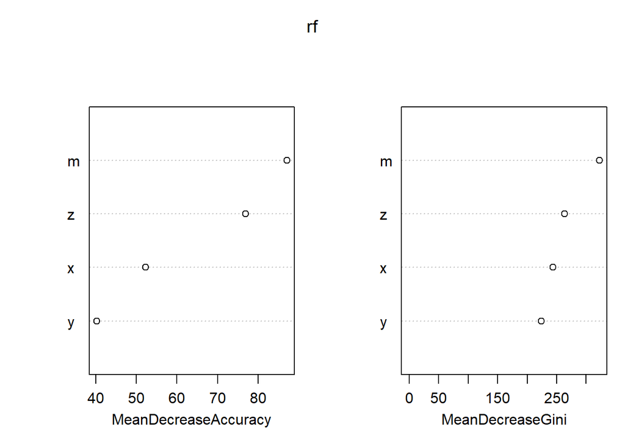

```r
varImpPlot(rf)
```

```r
# test accuracy
pred = predict(rf, test_data, type="response")


test_labels = test_data$label

tp = sum(test_labels == pred & pred == 1)
fp = sum(test_labels != pred & pred == 1)
tn = sum(test_labels == pred & pred == 0)
fn = sum(test_labels != pred & pred == 0)

accuracy = mean(test_labels == pred); accuracies[3] = accuracy
precision = tp / (tp + fp); precisions[3] = precision
recall = tp / (tp + fn); recalls[3] = recall
f1 = 2 * (precision * recall) / (precision + recall); f1s[3] = f1

cat(noquote(paste0("Random Forest\n\nAccuracy: ", round(accuracy,4),
                   "\nPrecision: ", round(precision,4),
                   "\nRecall: ", round(recall,4),
                   "\nF1: ", round(f1,4))))
```

```
## Random Forest
##
## Accuracy: 0.7676
## Precision: 0.6162
## Recall: 0.6854
## F1: 0.6489
```

```r
test_labels = factor(test_data$label, labels = c("sober", "intoxicated"))
pred_labels = factor(pred, labels = c("sober", "intoxicated"))

conf_matrix = table(Predicted = pred_labels, True = test_labels)
conf_matrix
```

```
##              True
## Predicted     sober intoxicated
##   sober         314          56
##   intoxicated    76         122
```

### 4. Boosting Model

```r
depth.acc.values = rep(NA, 4)
folds.acc.values = rep(NA, 7)

for (i in 1:4) {
  set.seed(12)

  boost = gbm(label ~ ., data = train_data, distribution = "gaussian", n.trees = 150, interaction.depth = i, cv.folds = 3)

  best_iter = gbm.perf(boost, method = "cv")
  pred = predict(boost, test_data, n.trees = best_iter, type = "response")

  test_labels = factor(test_data$label, labels = c("sober", "intoxicated"))
  pred_labels = factor(ifelse(pred < 1.5, "sober", "intoxicated"))

  depth.acc.values[i] = mean(test_labels == pred_labels)
}
```

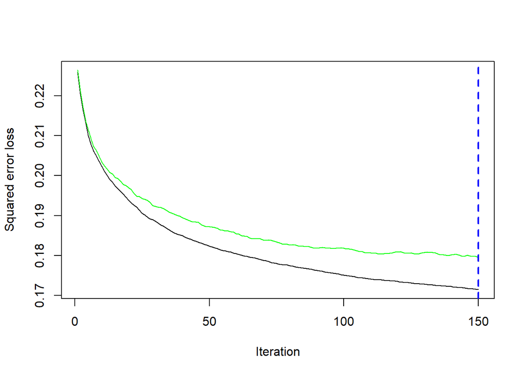

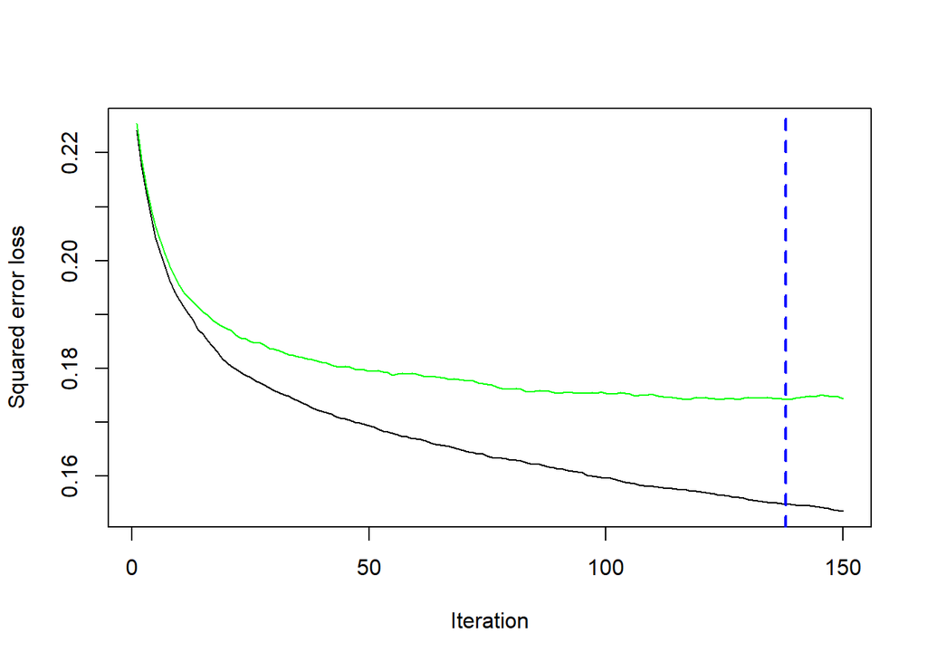

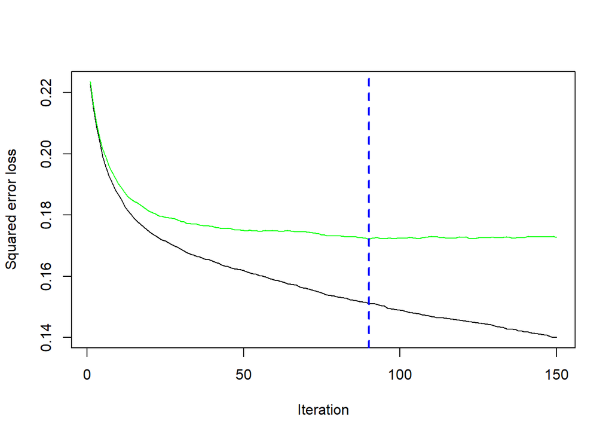

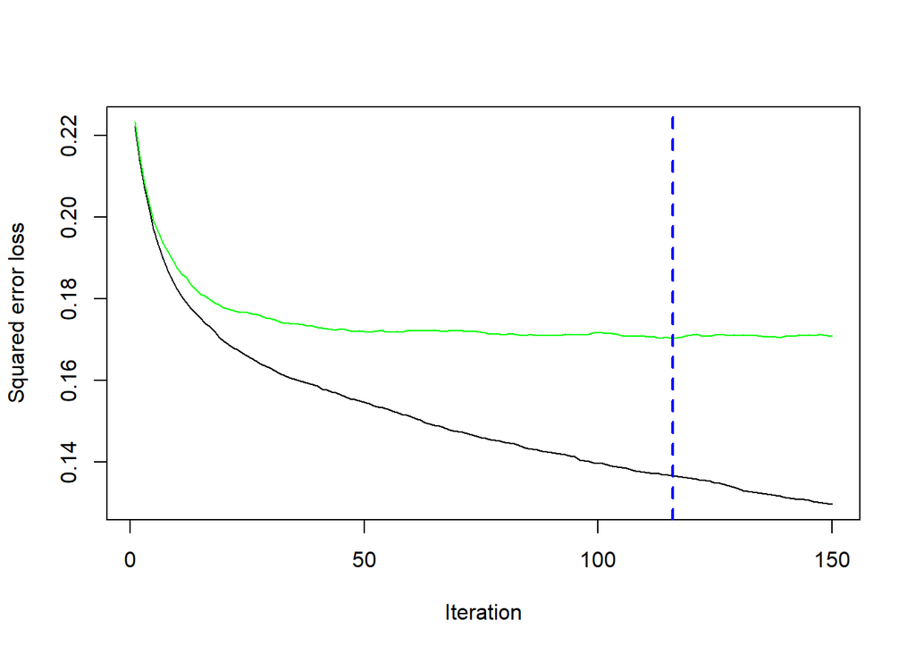

```r
depth = which.max(depth.acc.values)

names(depth.acc.values) = c(1,2,3,4)
depth.acc.values
```

```
##         1         2         3         4
## 0.7288732 0.7341549 0.7323944 0.7605634
```

```r
for (i in 2:7) {
  boost = gbm(label ~ ., data = train_data, distribution = "gaussian", n.trees = 150, interaction.depth = depth, cv.folds = i)

  best_iter = gbm.perf(boost, method = "cv")
  pred = predict(boost, test_data, n.trees = best_iter, type = "response")

  test_labels = factor(test_data$label, labels = c("sober", "intoxicated"))
  pred_labels = factor(ifelse(pred < 1.5, "sober", "intoxicated"))

  folds.acc.values[i] = mean(test_labels == pred_labels)
}
```

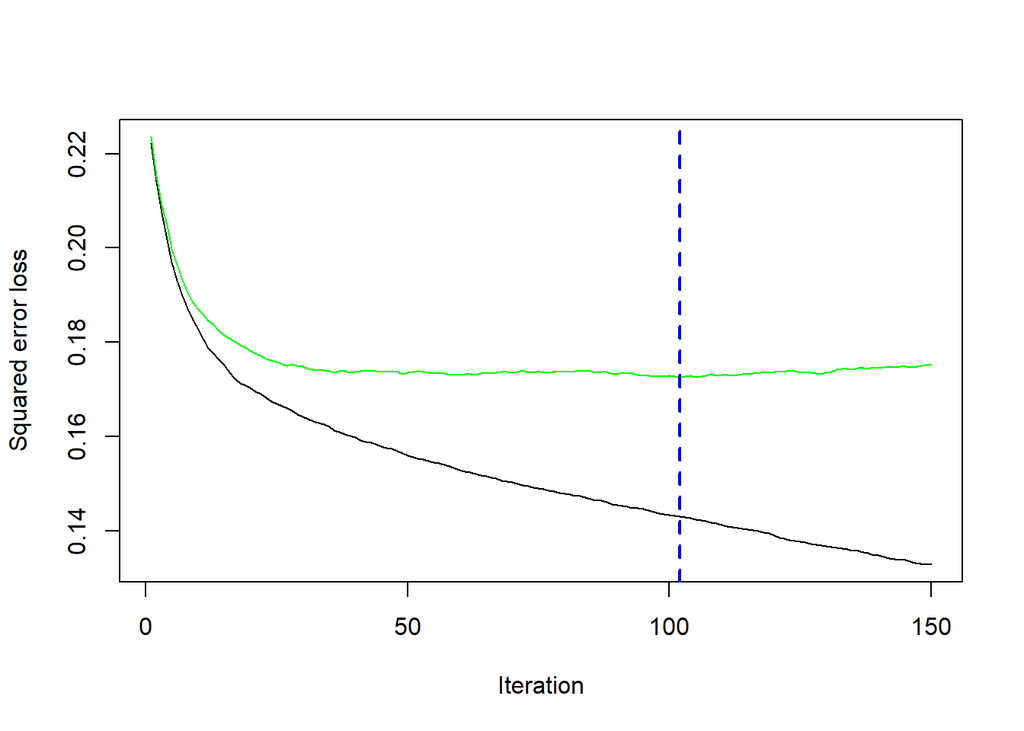

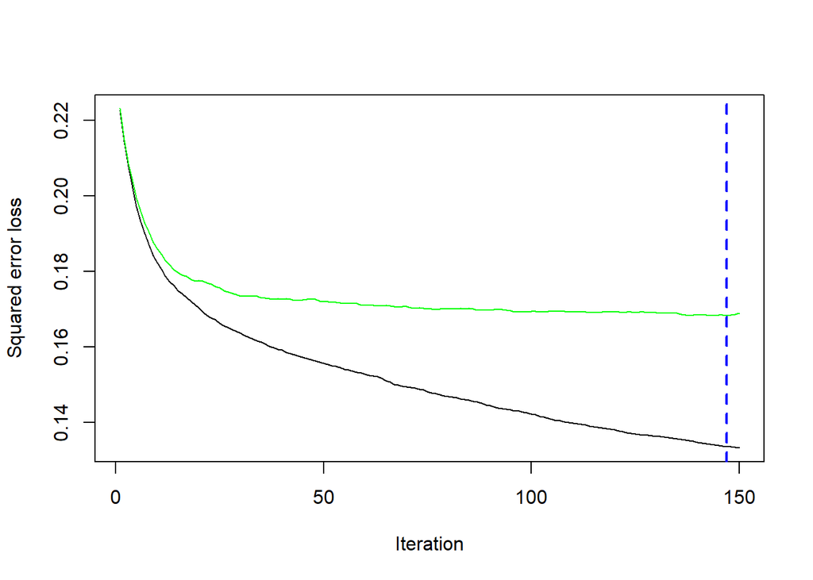

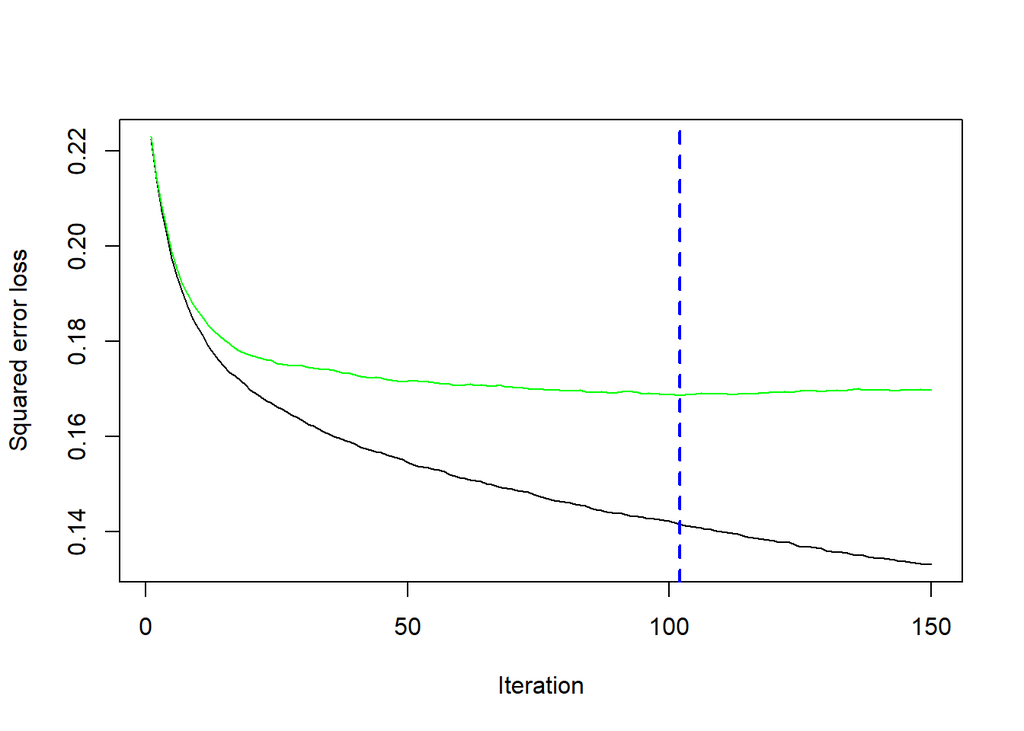

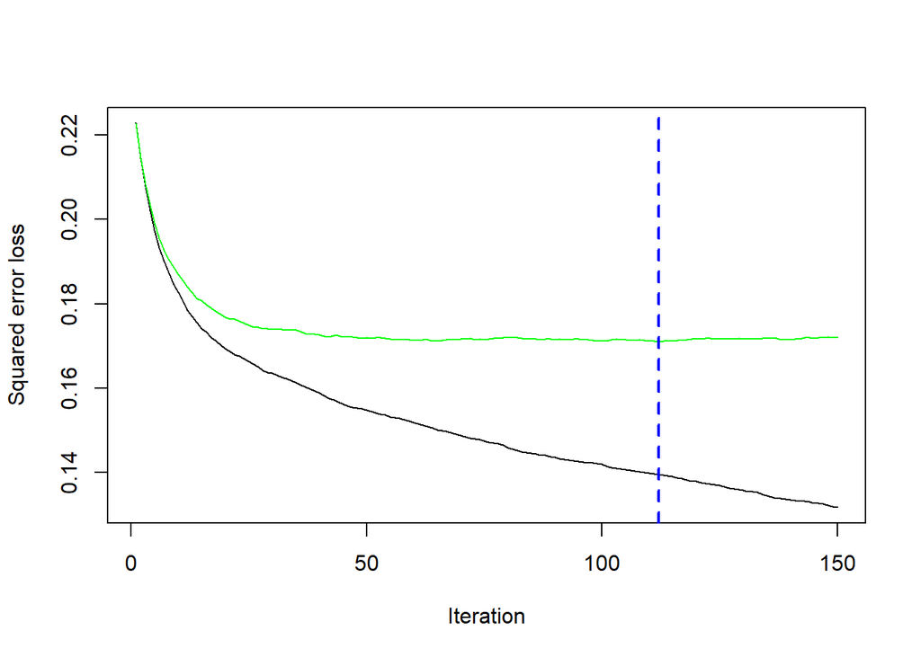

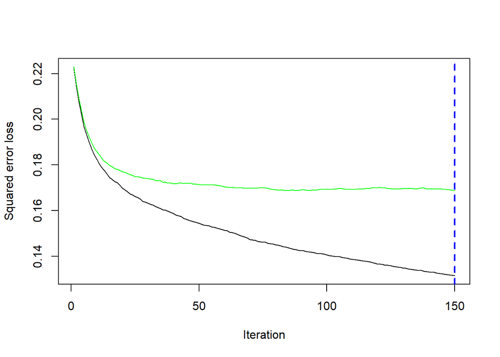

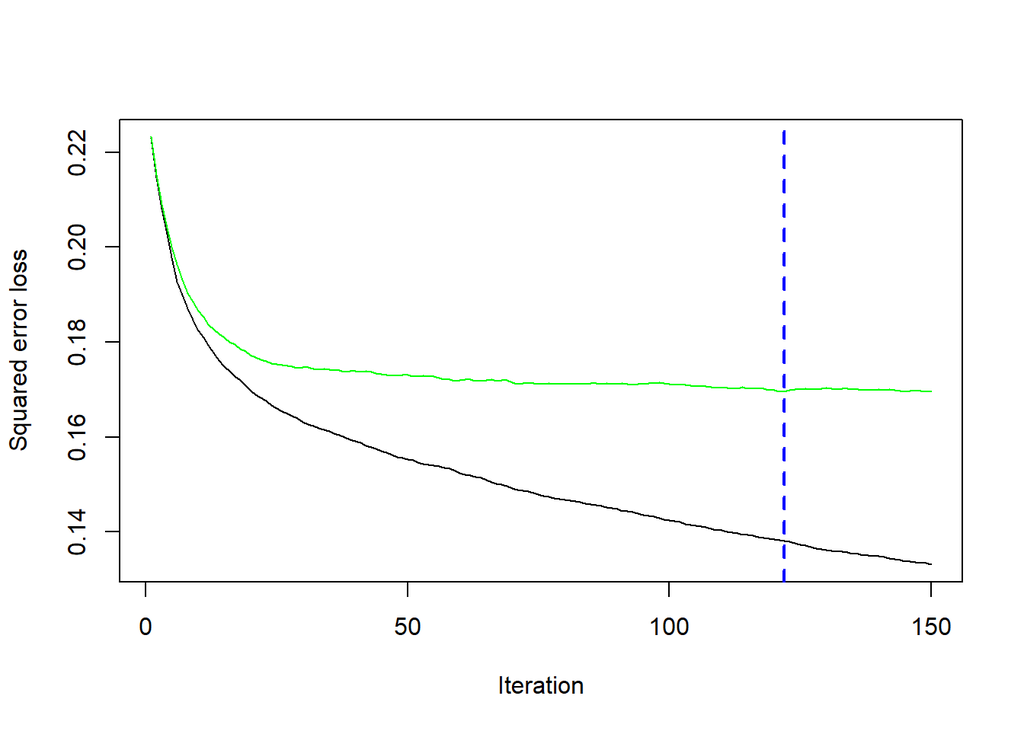

```r
folds = which.max(folds.acc.values)

names(folds.acc.values) = c(1:7)
folds.acc.values
```

```
##         1         2         3         4         5         6         7
##        NA 0.7359155 0.7306338 0.7429577 0.7271127 0.7288732 0.7235915
```

```r
set.seed(12)

boost = gbm(label ~ ., data = train_data, distribution = "gaussian", n.trees = 150, interaction.depth = depth, cv.folds = folds)
boost
```

```
## gbm(formula = label ~ ., distribution = "gaussian", data = train_data,
##     n.trees = 150, interaction.depth = depth, cv.folds = folds)
## A gradient boosted model with gaussian loss function.
## 150 iterations were performed.
## The best cross-validation iteration was 132.
## There were 4 predictors of which 4 had non-zero influence.
```

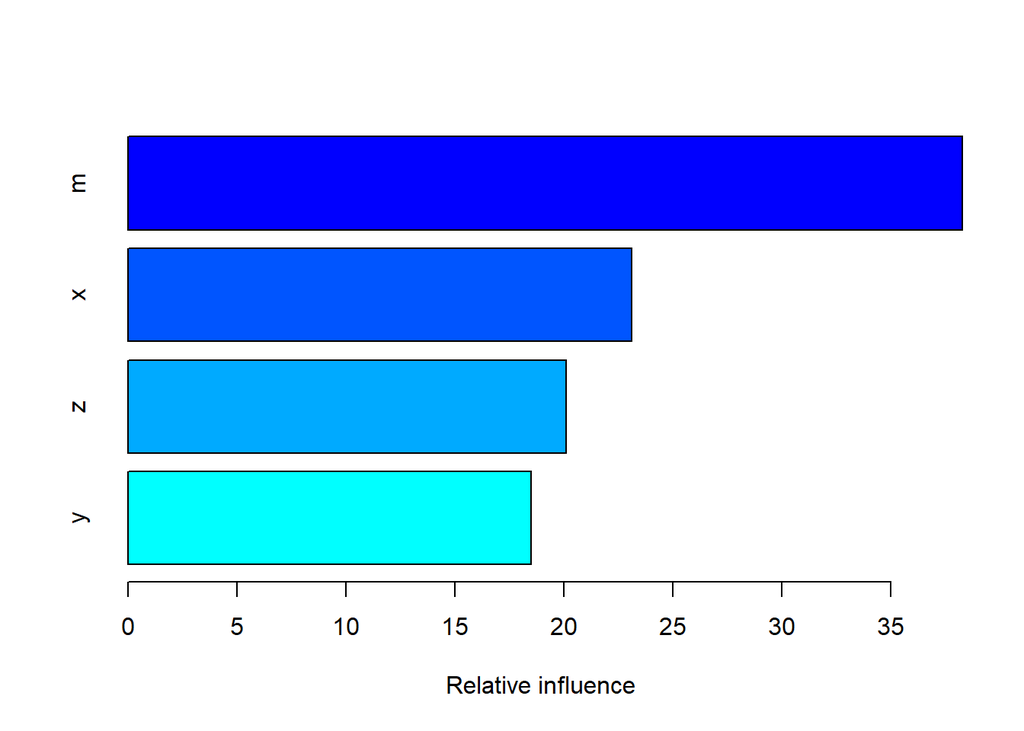

|  | var | rel.inf |
| --- | --- | --- |
| m | m | 38.27571 |
| x | x | 23.11336 |
| z | z | 20.09815 |
| y | y | 18.51278 |

```r
summary(boost)
```

```r
# test accuracy
best_iter = gbm.perf(boost, method = "cv")
```

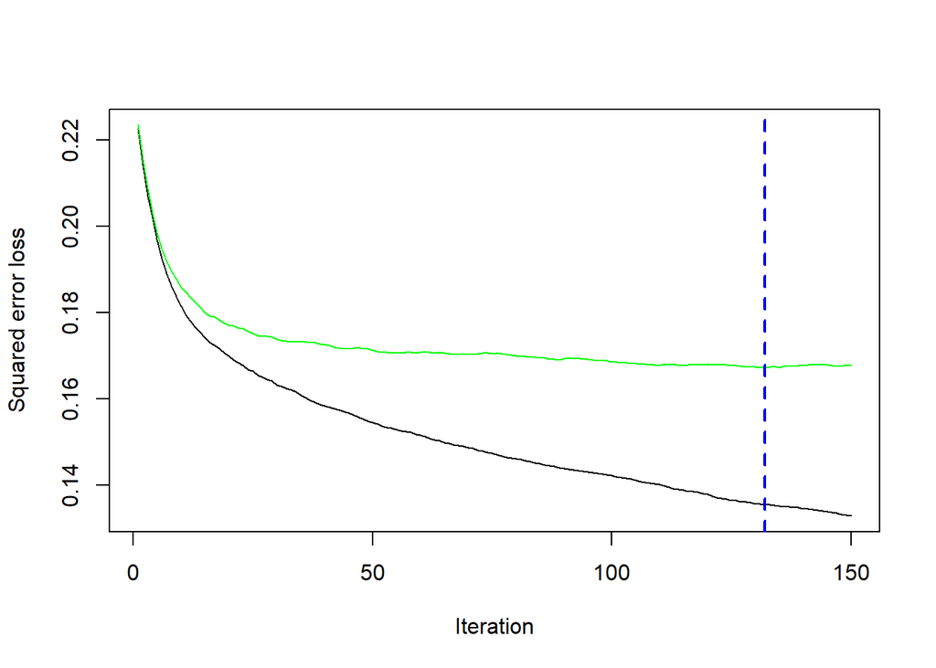

```r
pred = predict(boost, test_data, n.trees = best_iter, type = "response")

test_labels = factor(test_data$label, labels = c("sober", "intoxicated"))
pred_labels = factor(ifelse(pred < 1.5, "sober", "intoxicated"))


tp = sum(test_labels == pred_labels & pred_labels == "intoxicated")
fp = sum(test_labels != pred_labels & pred_labels == "intoxicated")
tn = sum(test_labels == pred_labels & pred_labels == "sober")
fn = sum(test_labels != pred_labels & pred_labels == "sober")

accuracy = mean(test_labels == pred_labels); accuracies[4] = accuracy
precision = tp / (tp + fp); precisions[4] = precision
recall = tp / (tp + fn); recalls[4] = recall
f1 = 2 * (precision * recall) / (precision + recall); f1s[4] = f1

cat(noquote(paste0("Boosting\n\nAccuracy: ", round(accuracy,4),
                   "\nPrecision: ", round(precision,4),
                   "\nRecall: ", round(recall,4),
                   "\nF1: ", round(f1,4))))
```

```
## Boosting
##
## Accuracy: 0.7447
## Precision: 0.5892
## Recall: 0.6124
## F1: 0.6006
```

```r
conf_matrix = table(Predicted = pred_labels, True = test_labels)
cm_swapped = conf_matrix[c(2, 1), ] # swap rows
cm_swapped
```

```
##              True
## Predicted     sober intoxicated
##   sober         314          69
##   intoxicated    76         109
```

### 5. Classification Tree Model

Run the classification tree model and obtain accuracy, precision, recall, and F1-score.

```r
tree = tree(label ~ ., data = train_data)

summary(tree)
```

```
##
## Classification tree:
## tree(formula = label ~ ., data = train_data)
## Variables actually used in tree construction:
## [1] "m" "x" "z"
## Number of terminal nodes:  8
## Residual mean deviance:  1.014 = 2295 / 2264
## Misclassification error rate: 0.3112 = 707 / 2272
```

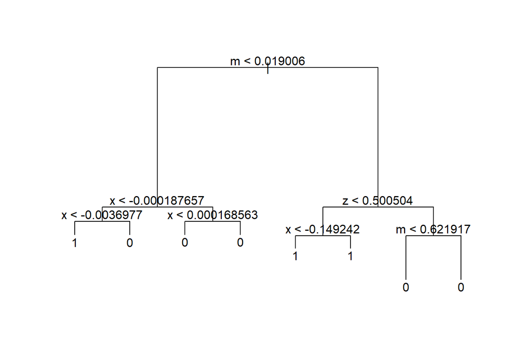

```r
plot(tree)
text(tree)
```

```r
pred = predict(tree, test_data, type = "class")

# test accuracy
test_labels = test_data$label

tp = sum(test_labels == pred & pred == 1)
fp = sum(test_labels != pred & pred == 1)
tn = sum(test_labels == pred & pred == 0)
fn = sum(test_labels != pred & pred == 0)

accuracy = mean(test_data$label == pred); accuracies[5] = accuracy
precision = tp / (tp + fp); precisions[5] = precision
recall = tp / (tp + fn); recalls[5] = recall
f1 = 2 * (precision * recall) / (precision + recall); f1s[5] = f1

cat(noquote(paste0("Classification Tree\n\nAccuracy: ", round(accuracy,4),
                   "\nPrecision: ", round(precision,4),
                   "\nRecall: ", round(recall,4),
                   "\nF1: ", round(f1,4))))
```

```
## Classification Tree
##
## Accuracy: 0.6567
## Precision: 0.4719
## Recall: 0.8034
## F1: 0.5946
```

```r
test_labels = factor(test_data$label, labels = c("sober", "intoxicated"))
pred_labels = factor(pred, labels = c("sober", "intoxicated"))

conf_matrix = table(Predicted = pred_labels, True = test_labels)
conf_matrix
```

```
##              True
## Predicted     sober intoxicated
##   sober         230          35
##   intoxicated   160         143
```

### 6. Support Vector Machine Model

First conduct parameter tuning on kernel, then run the SVM model and obtain accuracy, precision, recall, and F1-score.

```r
kernel.options = c("polynomial", "radial", "sigmoid")
kernel.acc.values = rep(NA, 3)

for (i in 1:3) {
  svm.model = svm(label ~ ., data = train_data, kernel = kernel.options[i])

  pred = predict(svm.model, test_data, type="response")
  test_labels = test_data$label

  kernel.acc.values[i] = mean(test_labels == pred)
}
kernel = kernel.options[which.max(kernel.acc.values)]

names(kernel.acc.values) = kernel.options
kernel.acc.values
```

```
## polynomial     radial    sigmoid
##  0.6813380  0.6795775  0.6971831
```

```r
svm.model = svm(label ~ ., data = train_data, kernel = kernel)

# test accuracy
pred = predict(svm.model, test_data, type="response")


test_labels = test_data$label

tp = sum(test_labels == pred & pred == 1)
fp = sum(test_labels != pred & pred == 1)
tn = sum(test_labels == pred & pred == 0)
fn = sum(test_labels != pred & pred == 0)

accuracy = mean(test_labels == pred); accuracies[6] = accuracy
precision = tp / (tp + fp); precisions[6] = precision
recall = tp / (tp + fn); recalls[6] = recall
f1 = 2 * (precision * recall) / (precision + recall); f1s[6] = f1

cat(noquote(paste0("Support Vector Machine\n\nAccuracy: ",
                   round(accuracy,4),
                   "\nPrecision: ", round(precision,4),
                   "\nRecall: ", round(recall,4),
                   "\nF1: ", round(f1,4))))
```

```
## Support Vector Machine
##
## Accuracy: 0.6972
## Precision: 0.5625
## Recall: 0.1517
## F1: 0.2389
```

```r
test_labels = factor(test_data$label, labels = c("sober", "intoxicated"))
pred_labels = factor(pred, labels = c("sober", "intoxicated"))

conf_matrix = table(Predicted = pred_labels, True = test_labels)
conf_matrix
```

```
##              True
## Predicted     sober intoxicated
##   sober         369         151
##   intoxicated    21          27
```